# Leistungsentwicklung bei Wettkämpfen

##Einführung

###Zielstellung

- Beschreibung der bisherigen Entwicklung
- Bestimmung des Entwicklungstrends
- Hochrechnung über die Erreichung von Leistungszielen
- Erkennung von Potentialen, also in welchem Teilbereich das größte Entwicklungspotential steckt.

###Datenbasis

Im Zeitraum vom 2017-03-01 bis 2019-06-01 wurden 85 Wettkämpfe geschossen. Aus statistischen Gründen werden dabei ausgekoppelte Wertungen (Präzision und Kombi) als einzelner Wettkampf betrachtet. Auch mehrfache Starts in unterschiedlichen Disziplinen/Waffen werden jeweils als eigener Wettkampf betrachtet.

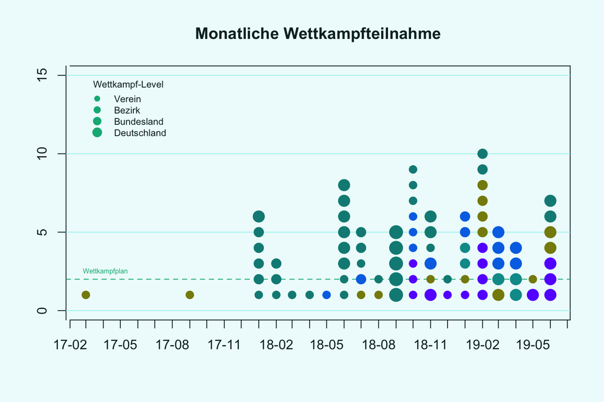

Verteilung Disziplin auf Waffen

|  | F12 | HPS | PPQ | Ruger | Xesse | Sum |
| --- | --- | --- | --- | --- | --- | --- |
| Fallscheibe | 0 | 0 | 0 | 2 | 1 | 3 |
| IPSC | 0 | 1 | 2 | 0 | 2 | 5 |
| Kombi | 0 | 3 | 2 | 0 | 9 | 14 |
| Mehrdistanz | 3 | 2 | 4 | 4 | 7 | 20 |
| Präzision | 0 | 4 | 2 | 0 | 10 | 16 |
| Speed | 2 | 4 | 4 | 6 | 10 | 26 |
| Speed-Steel | 0 | 0 | 0 | 1 | 0 | 1 |
| Sum | 5 | 14 | 14 | 13 | 39 | 85 |

###Begriffsbestimmung

**Präzision**

In zwei Serien von jeweils 5 Minuten werden jeweils 10 Schuss in einem beliebigem Anschlag aus 25m auf eine BDS9-Scheibe abgegeben.

**Kombi**

Zusätzlich zu *Präzision* 2x5 Schuss im Interval 3-7 Sekunden, 5 Schuss in einer 10 Sekunden und 10 Schuss in einer 20 Sekunden Serie abgegeben.

**Speed**

in sechs Serien a fünf Schuss werden auf eine Speed-Scheibe geschossen. Die ermittelte Zeit wird von geschossenen Ringen abgezogen.

**Mehrdistanz**

40 Schuss aus verschiedenen Anschlägen und verschiedenen Entfernungen

**Fallscheibe**

in sechs Serien a fünf Schuss werden auf Metallplatten geschossen. Ziel ist eine möglichst niedrige Zeit.

**Speed-Steel**

Vergleichbar zu Fallscheibe, noch experimentell. Wird gegeneinander geschossen und der Gewinner kommt eine Runde weiter.

**IPSC**

Teilnahme an einem IPSC-Wettkampf. Eine vergleichbare Leistung gibt hier nicht, eine Leistungsentwicklung kann nur indirekt durch Platzierungen und Level des Wettkampfs ermittelt werden.

###Leistungsziele

####Anforderungen Qualifikation Landesmeisterschaft NRW

|  | Präzision | Kombi | Mehrdistanz | Speed | Fallscheibe | IPSC |
| --- | --- | --- | --- | --- | --- | --- |
| Kurzwaffe | 170 | 300 | 320 | 150 | 0 | 0 |
| Langwaffe | 0 | 0 | 270 | 225 | 0 | 0 |
| Selbstlade-Flinte | 0 | 0 | 210 | 90 | 0 | 0 |

####Anforderungen Qualifikation Deutsche Meisterschaft

|  | Präzision | Kombi | Mehrdistanz | Speed | Fallscheibe | IPSC |
| --- | --- | --- | --- | --- | --- | --- |
| Kurzwaffe | 184 | 346 | 360 | 180 | 0 | 0 |
| Langwaffe | 0 | 0 | 270 | 241 | 0 | 0 |
| Selbstlade-Flinte | 0 | 0 | 225 | 120 | 0 | 0 |

####Anforderungen Deutscher Meister

|  | Präzision | Kombi | Mehrdistanz | Speed | Fallscheibe | IPSC |
| --- | --- | --- | --- | --- | --- | --- |
| Kurzwaffe | 197 | 380 | 385 | 240 | 0 | 0 |
| Langwaffe | 0 | 0 | 290 | 265 | 0 | 0 |
| Selbstlade-Flinte | 0 | 0 | 290 | 160 | 0 | 0 |

###Farb- und Symbolkodierung

Bei der Auswertung der SCATT-Daten wird im Augenblick nicht zwischen verschiedenen Waffen eines Waffentyps unterschieden. Zur optischen Erkennung welche Trainingsession mit welcher Waffe geschossen wurde, wird durchgängig mit diesem Farbschema gearbeitet:

| Waffe | Waffentyp | Farbcode |
| --- | --- | --- |
| F12 | Langwaffe |  |
| HPS | Kurzwaffe |  |
| PPQ | Kurzwaffe |  |
| Ruger | Langwaffe |  |
| Xesse | Kurzwaffe |  |

## Entwicklung

### Präzision

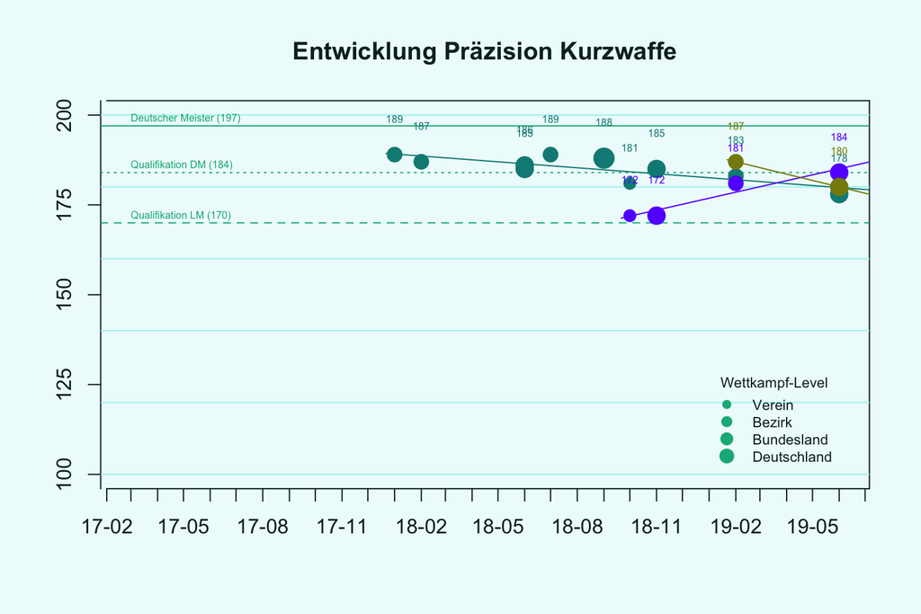

### Kombi

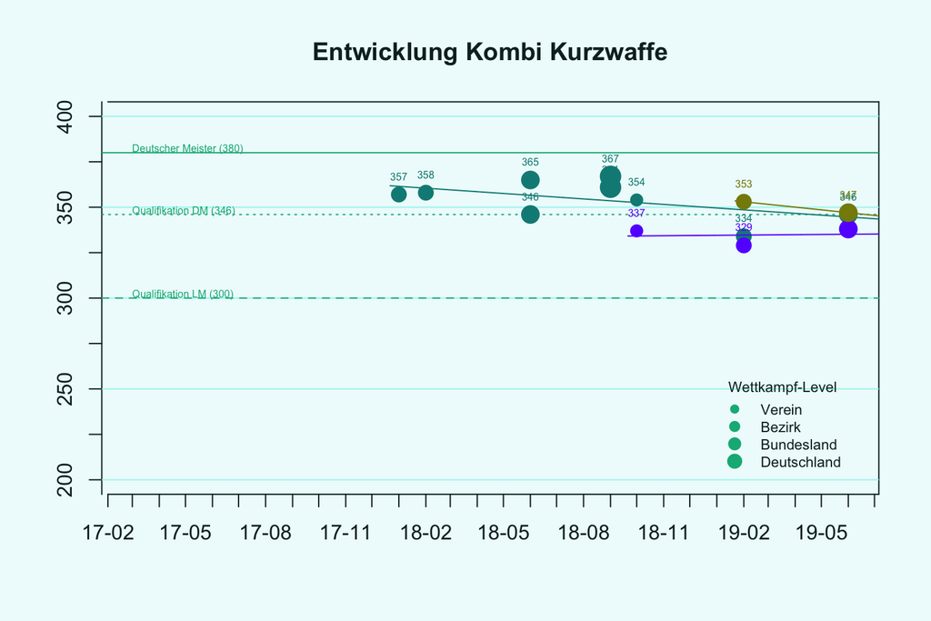

### Mehrdistanz

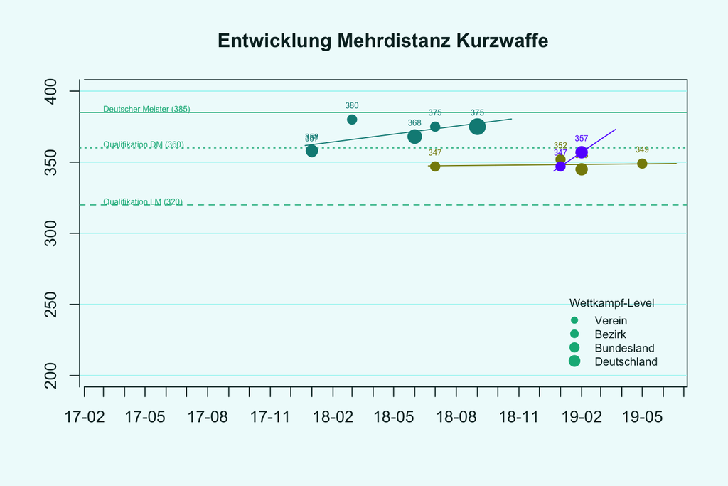

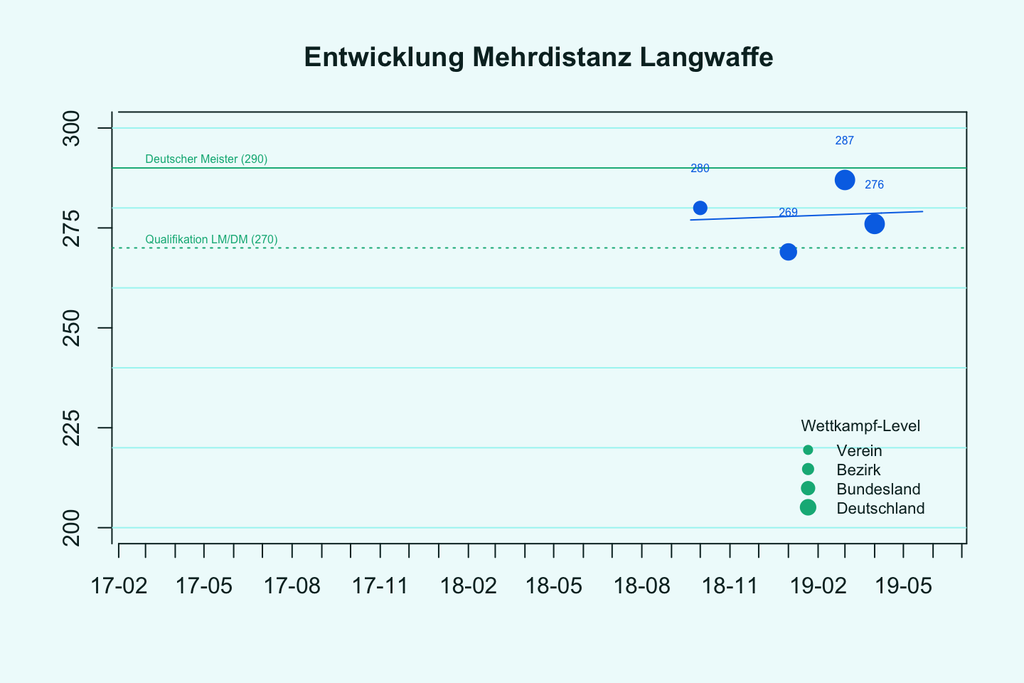

[figure not shown]

### Speed

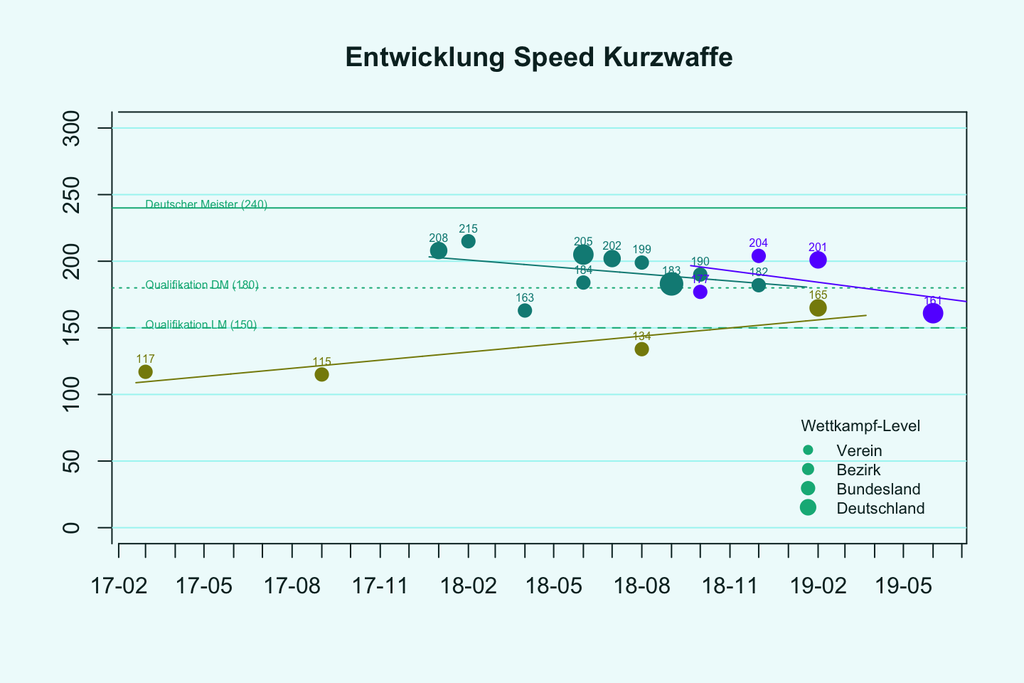

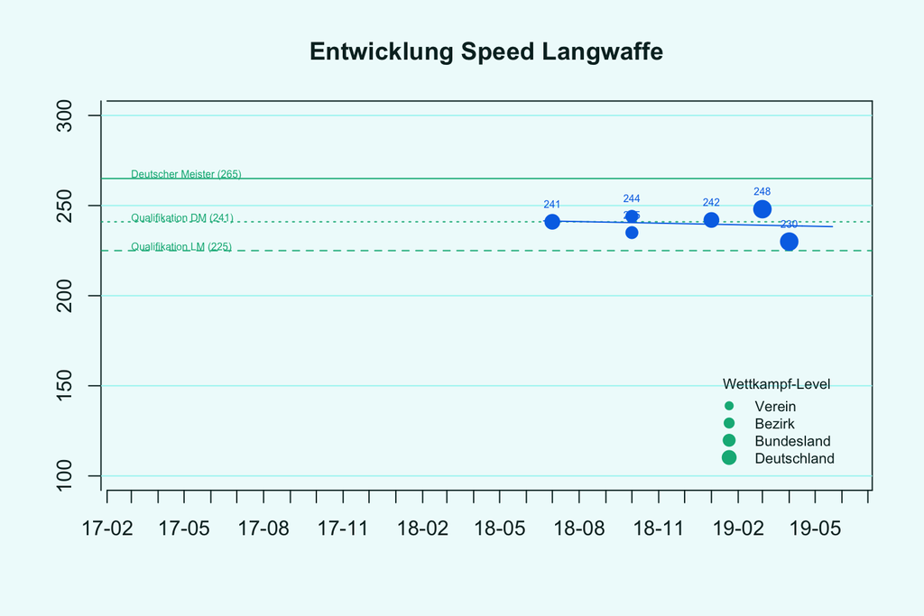

[figure not shown]

## Abschluss

### Reportdatum

Der Report wurde am 2019-09-01 aus den Aufzeichnungen der Datei <<*WK_Protokoll.csv*>> erstellt.